# Mendota_Volume

Lauren A. Knose, ORISE-EPA

2023-02-14

The purpose of this program is to calculate the volumes of each lake layer (epilimnion, hypolimnion, sediments) to support mass balance calculations.

Step 1. set working directory and load dependent packages:

```r
setwd("~/ORISE_EPA_LKnose/Analysis/GitHub/LakeLegacyNP")
library(ggplot2)
library(dplyr)
library(zoo)
library(lubridate)
library(DiagrammeR)
```

Step 2. Load the data into R:

```r
Secchi <- read.csv(file.choose()) #choose ntl31_v9_secchi.csv
```

Note the metadata can be found at: https://portal.edirepository.org/nis/metadataviewer?packageid=knb-lter-ntl.31.32

Step 3. Filter and transform the data:

```r
ME_Secchi<- Secchi %>%
  filter(lakeid=="ME") %>% # filters data for Lake Mendota
  mutate(sampledate=as.Date(sampledate, origin="1899-12-30"), #tells R to format
          #data as date
         mo=month(ymd(sampledate)), # creates a new field with month
         yr_mo=as.yearmon(sampledate)) # creates a new field that holds the
          #month and year for each record
```

Step 4. Summarize and view the data:

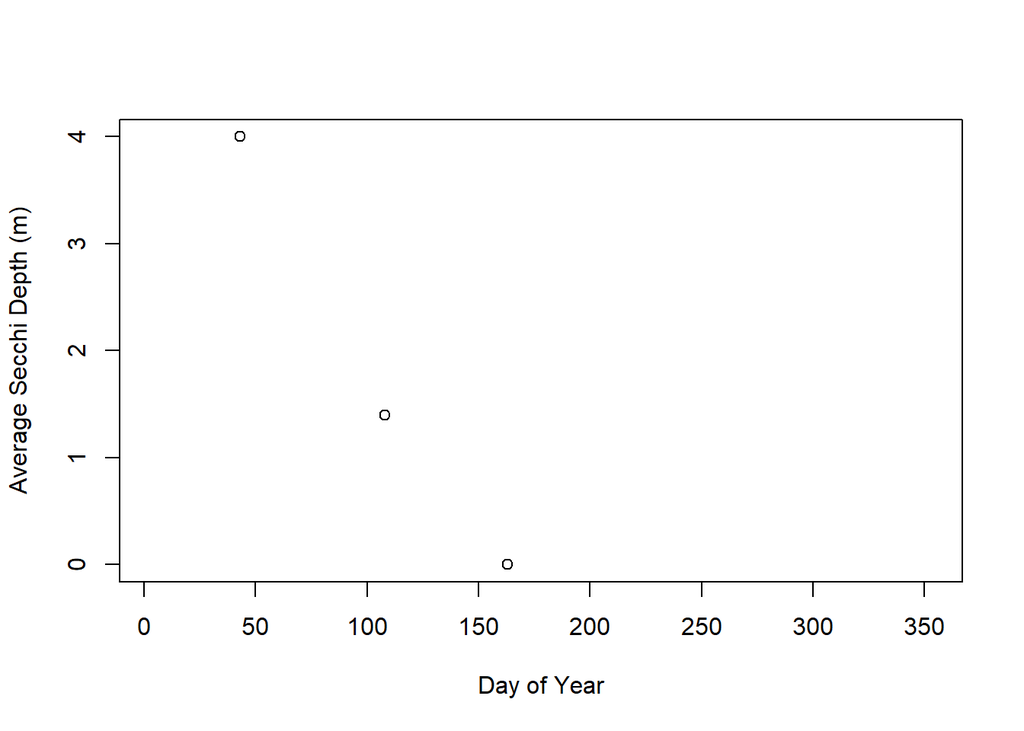

```r
ME_Secchi_day <- ME_Secchi %>%
  group_by(daynum) %>% #group all data for that day of year (multiple years)
  summarize(secview_avg= mean(secview, na.rm=TRUE), #mean of Secchi with viewer
            secnview_avg= mean(secnview, na.rm=TRUE)) #mean of Secchi without viewer

plot(ME_Secchi_day$secview_avg~ME_Secchi_day$daynum, #plot Secchi by day of yr
     xlab="Day of Year", #add x axis label
     ylab="Average Secchi Depth (m)") #add y axis label) #plot Secchi with viewer
```

There are only 3 observations so I can’t use this data. I need to use the Secchi disk depth (m) measured without the viewer. I plotted this data, below.

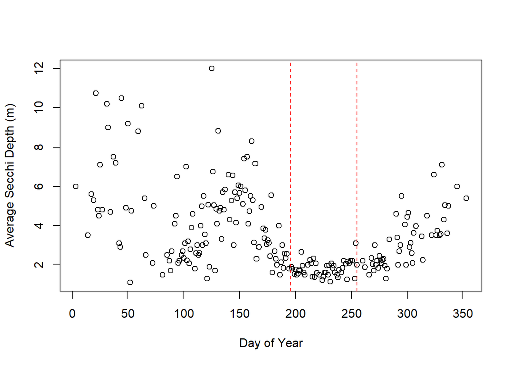

```r
plot(ME_Secchi_day$secnview_avg~ME_Secchi_day$daynum, #plot Secchi by day of yr
     xlab="Day of Year", #add x axis label
     ylab="Average Secchi Depth (m)") #add y axis label
abline(v=195, col="red", lty="dashed") #Summer range for Secchi
abline(v=255, col="red", lty="dashed") #Summer range for Secchi
```

The figure above represents the change in transparency of the lake across Julian day. A clear water column would have a high Secchi depth, whereas a turbid water column would have a low Secchi depth. The red dashed lines represent the time of year when the Secchi disk depth doesn’t change (slope ~ 0), which corresponds to July 15 to September 12. This means that on average the summer season when the water transparency is consistently low (corresponding to CyanoHAB presence), is from mid-July to mid-September. Likely, fall turnover mid-September can be attributed to increasing transparency and the reduction of CyanoHABs.

There appears to be a polynomial relationship with high variability during Winter and Spring, and an exponential or linear increase during Fall, also with high variability. I will have to perform separate analyses to describe the patterns during Winter, Spring, and Fall.

If I isolate the Summer period, I can perform a regression test to see if there is no change in Secchi depth from mid-July to mid-September.

```r
z<- lm(secnview_avg~daynum, data = subset(ME_Secchi_day,
                                         daynum > 195 & daynum <255))
summary(z) #prints out the regression results testing whether y changes with x
```

```
##
## Call:
## lm(formula = secnview_avg ~ daynum, data = subset(ME_Secchi_day,
##     daynum > 195 & daynum < 255))
##
## Residuals:
##      Min       1Q   Median       3Q      Max
## -0.66498 -0.24270 -0.01935  0.23751  1.20618
##
## Coefficients:
##             Estimate Std. Error t value Pr(>|t|)
## (Intercept) 1.023165   0.747996   1.368    0.178
## daynum      0.003428   0.003320   1.032    0.307
##
## Residual standard error: 0.3875 on 45 degrees of freedom
## Multiple R-squared:  0.02314,    Adjusted R-squared:  0.001433
## F-statistic: 1.066 on 1 and 45 DF,  p-value: 0.3074
```

Now to calculate the volumes of the epilimnion and hypolimnion, I need Lake Mendota’s average depth and surface area.

Step 5. Set up terms and perform basic calculations:

```r
Z_avg<- 12.8 #average depth of Lake Mendota, WI in meters
V_tot<- 500000000 #total water volume of Lake Mendota, WI in m^3
t_res<- 4.5 #residence time of Lake Mendota, WI in years
LSA <- 39.4 #surface area of Lake Mendota, WI in km^2
km2_m2<- 1*1000000 #conversion factor from km^2 to m^2
```

Calculate the compensation depth from the mean summer Secchi disk depth:

```r
sum_ME_Secchi<- ME_Secchi_day %>%
  filter(daynum>=195 & daynum < 255) %>% #filter the data to summer HAB season
  mutate(secview_avg=NULL) # remove the unnecessary data

sum<- sum_ME_Secchi %>%
  summarise(mean=mean(sum_ME_Secchi$secnview_avg, na.rm=TRUE),
          min=min(sum_ME_Secchi$secnview_avg, na.rm=TRUE),
          max=max(sum_ME_Secchi$secnview_avg, na.rm=TRUE))
Z_cd<-sum$mean*2 #compensation depth is 2x the Secchi depth
Z_cd
```

```
## [1] 3.586489
```

Calculate the epilimnion volume using the cylinder shape:

```r
r <- sqrt((LSA*km2_m2)/pi)
V_epi<- (pi*r^2*Z_cd) #volume of cylinder is pi*r^2*h
```

Based on a lake surface area of 39.4 km^2, and a compensation depth of 3.5864894 m, the volume of the epilimnion is 1.4130768^{8} m^3.

Calculate the hypolimnion volume using the spherical bowl shape:

```r
Z_hypo<- Z_avg - Z_cd #cap height of bowl is the avg depth - compensation depth
V_hypo<- pi*(Z_hypo/6)*((3*(r^2)) + Z_hypo^2) #vol of spherical bowl is
            # pi*(h/6)*(3*(r^2) + h^2)
```

Based on a lake surface area of 39.4 km^2, and a compensation depth of 3.5864894 m, the volume of the hypolimnion is 1.8150657^{8} m^3.

Calculate the sediment volume using the hypo’s spherical cap:

```r
Z_sed = 0.1 #depth of unconsolidated sediments in m (from Nurnberg 1988)
A_hypo<- pi*(r^2 + Z_hypo^2) #surface area of spherical cap
V_sed = A_hypo*Z_sed #volume is area * height in m^3
```

Based on the hypolimion surface area of 3.9400267^{7} m^2, and a depth of 0.1 m, the volume of the sediments is 3.9400267^{6} m^3.

How do we validated these numbers? We could use the Generalized Lake Model (GLM), or USGS bathymetry-based calculations. More information about the GLM can be found here: https://aed.see.uwa.edu.au/research/models/glm/#